# RedWineDataSetEDA

# Multivariate Analysis

### Talk about some of the relationships you observed in this part of the investigation. Were there features that strengthened each other in terms of looking at your feature(s) of interest?

By looking into the strongest COR values, we notice that fixed acidity and citric acid correlation coefficient is the strongest 0.67. So that we wanted to examine their behavior with quality. Both have positive correlation with quality. Citric has a stronger positive COR = 0.22 comparing to the fixed acidity COR = 0.12. Despite of the positive strong correlation amongst themselves and positive COR with quality, I don’t see both have a big of a common impact on quality. They do have positive on quality individually but not together. We still more of very good quality skewed to the upper right side a little bit.

On the other hand, looking into the strongest negative correlation between chemicals which is between pH and fixed acidity. I have added some other plots to examine relationships of different chemical elements and their impact on quality.

### Were there any interesting or surprising interactions between features?

Yes, the correlation between alcohol and citric acid. Both have positive correlation with quality separately. But when you take both of them and plot them against each other, weak correlation between them which is verified by COR = 0.109

### OPTIONAL: Did you create any models with your dataset? Discuss the strengths and limitations of your model.

# Final Plots and Summary

### Plot One

Alcohol and dencity, coloring by quality variable. An interesting relation with negative correlation

Plotting alcohol vs density

```
## [1] -0.4961798
```

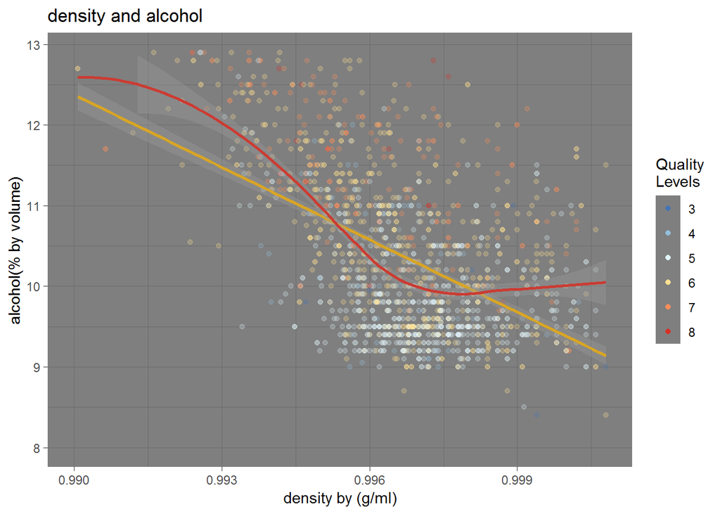

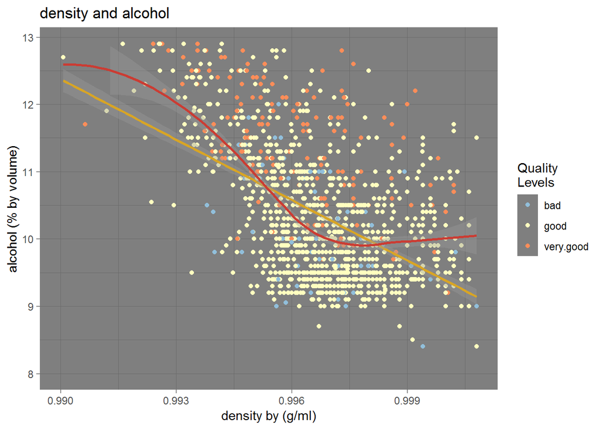